# Resolução do Exemplo 1

Prof. André Monticeli

## Aplicações da Análise de Componente Principais - PCA

Vamos carregar o conjunto de dados de várias empresas. O arquivo de dados é o *dados_pca-exemplo1.csv*.

```r
library(haven)
dados <- read.csv("dados_pca-exemplo1.csv")
```

### 1-Normalizando os dados

Em seguida, vamos normalizar (padronizar) os dados, utilizando a função scale().

```r
head(dados) #Observe que a primeira coluna é só identificação da empresa
```

```
##   Empresa Clientes Vendas Tamanho N_Funcionarios
## 1       1      907  11.20      30            300
## 2       2      926  11.05      45            430
## 3       3      506   6.84      52            510
## 4       4      741   9.21      36            390
## 5       5      789   9.42      24            265
## 6       6      889  10.08      56            450
```

```r
colMeans(dados[, 2:ncol(dados)])  #calcular a média de coluna por coluna
```

```
##       Clientes         Vendas        Tamanho N_Funcionarios
##       731.1500         8.8055        51.6500       490.5000
```

```r
dados_norm <- scale(dados [, 2:ncol(dados)])
head(dados_norm)
```

```
##         Clientes     Vendas     Tamanho N_Funcionarios
## [1,]  0.97773687  1.4563878 -1.02938413    -0.97464184
## [2,]  1.08337805  1.3651545 -0.31618496    -0.30953192
## [3,] -1.25184792 -1.1954605  0.01664131     0.09976649
## [4,]  0.05476661  0.2460258 -0.74410446    -0.51418113
## [5,]  0.32164958  0.3737525 -1.31466380    -1.15370989
## [6,]  0.87765576  0.7751791  0.20682776    -0.20720732
```

Vamos verificar se os dados estão nomalizados, ou seja, com média 0 e desvio padrão igual a 1.

```r
colMeans(dados_norm) #Média é 0
```

```
##       Clientes         Vendas        Tamanho N_Funcionarios
##   1.387779e-16  -2.053913e-16   7.771561e-17   2.220446e-17
```

```r
sd(dados_norm[,1]) #Desvio-padrão é 1
```

```
## [1] 1
```

### 2-Matriz de correlação

Agora vamos calcular a matriz de correlação dos dados normalizados.

```r
mat_cor <- cor(dados_norm)
print(mat_cor, digits = 2)
```

```
##                Clientes Vendas Tamanho N_Funcionarios
## Clientes           1.00   0.95   -0.26          -0.23
## Vendas             0.95   1.00   -0.33          -0.27
## Tamanho           -0.26  -0.33    1.00           0.96
## N_Funcionarios    -0.23  -0.27    0.96           1.00
```

Podemos ver uma forte correlação entre Clientes e Vendas (0,95) e Tamanho e Número de Funcionários (0,96).

Podemos também gerar os gráficos dessas correlações, para melhor visualização.

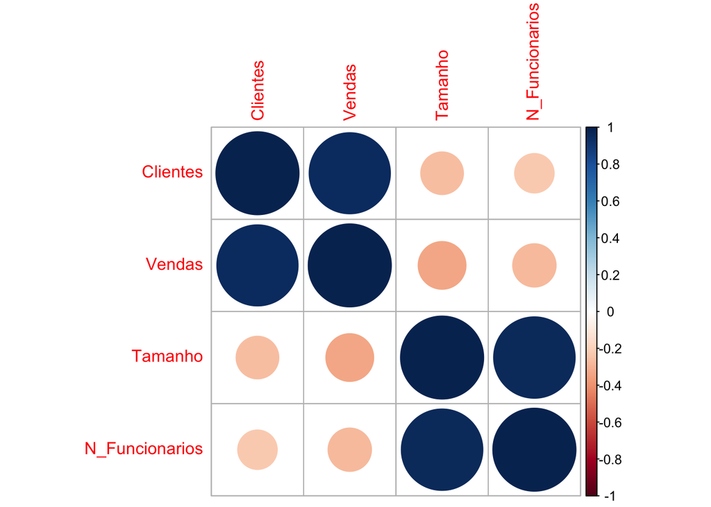

```r
if(!require(corrplot)) install.packages("corrplot")
library(corrplot)
corrplot(mat_cor, method = "circle")
```

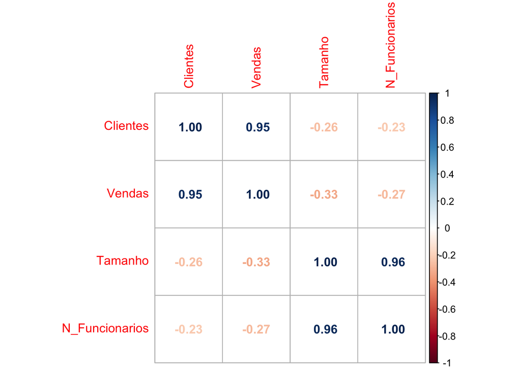

```r
corrplot(mat_cor, method = "number")
```

Lembrando:

O resultado da matriz de correlação pode ser interpretado da seguinte forma:

- Quanto maior o valor, maior a correlação positiva entre as duas variáveis.
- Quanto mais próximo o valor de -1, mais negativamente correlacionados eles são.

### 3-Autovalores

Agora vamos calcular os autovalores, para ver o quanto da variabilidade é explicada por cada componente.

```r
ev <- eigen(mat_cor)
print(ev$values, digits = 2)
```

```
## [1] 2.506 1.414 0.051 0.029
```

Calculando o quanto cada autovalor corresponde, temos

```r
ev$values/sum(ev$values)
```

```
## [1] 0.62647295 0.35347491 0.01277431 0.00727782
```

Observe que, o primeiro corresponde a 62,64% da variabilidade, o segundo a 35,35%, ou seja, estes dois representam cerca de 97,99%. Portanto, indica-se que dois componentes principais explicaria 97,99% da variabilidade dos dados.

### 5-Calculando PCA

Primeiro, o princomp() calcula o PCA, e a função summary() mostra o resultado.

```r
resultado <- princomp(dados_norm)
summary(resultado)
```

```
## Importance of components:
##                          Comp.1    Comp.2     Comp.3     Comp.4
## Standard deviation     1.542918 1.1589671 0.22032336 0.16630008
## Proportion of Variance 0.626473 0.3534749 0.01277431 0.00727782
## Cumulative Proportion  0.626473 0.9799479 0.99272218 1.00000000
```

Observamos que foram gerados quadro componentes principais (Comp.1 a Comp.4), que também correspondem ao número de variáveis nos dados.

Cada componente explica uma porcentagem da variação total do conjunto de dados. Na seção **Proporção da variância**, o primeiro componente principal explica quase 62,64% da variação total. O segundo explica 35,35% da variação total. Os dois primeiros, observando a **Proporçao cumulativa** explica 97,99%, ou seja, os dados podem ser representados pelos dois primeiros componentes principais.

#### Visualização dos Componentes Principais

A primeira abordagem da lista é o gráfico scree. Ele é usado para visualizar a importância de cada componente principal e pode ser usado para determinar o número de componentes principais a serem retidos. O gráfico scree pode ser gerado usando a função fviz_eig().

```r
if(!require(factoextra)) install.packages("factoextra")
```

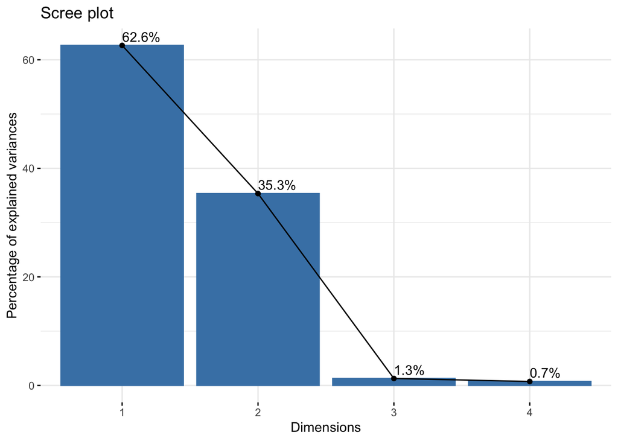

```r
library(factoextra)
fviz_eig(resultado, addlabels = TRUE)
```

Esse gráfico mostra os valores próprios em uma curva descendente, do maior para o menor. Os dois primeiros componentes podem ser considerados os mais significativos, pois contêm quase 97,99% do total de informações dos dados.

#### Definindo o número de componentes principais

Vamos utilizar o critério de Kaiser para definir o número de componentes principais.

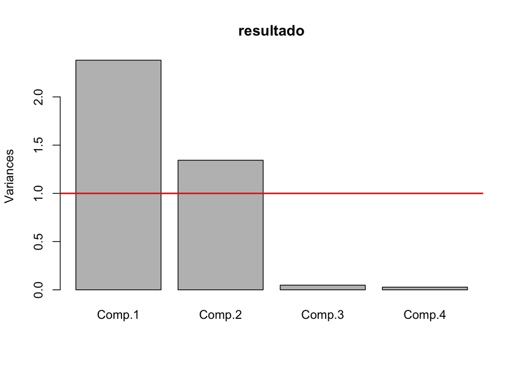

```r
plot(resultado)
abline(h = 1, col = "red", lwd = 2) #insere a linha horizontal)
```

Por fim, podemos criar um biplot – um gráfico que projeta cada uma das observações do conjunto de dados em um gráfico de dispersão que usa o primeiro e o segundo componentes principais como eixos:

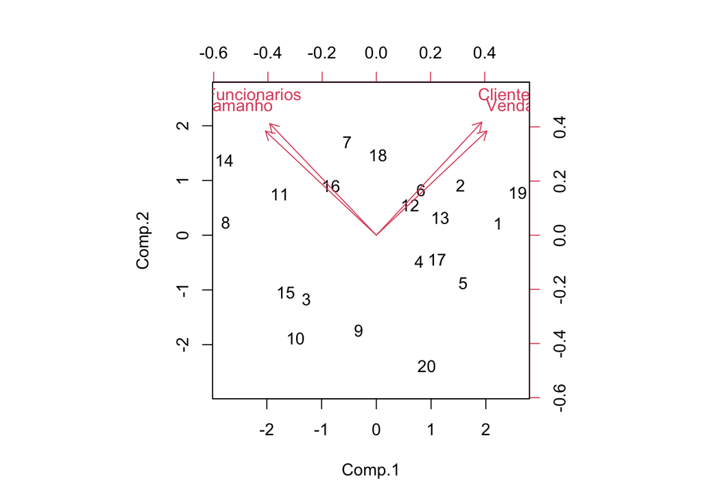

```r
biplot(resultado, scale=0)
```

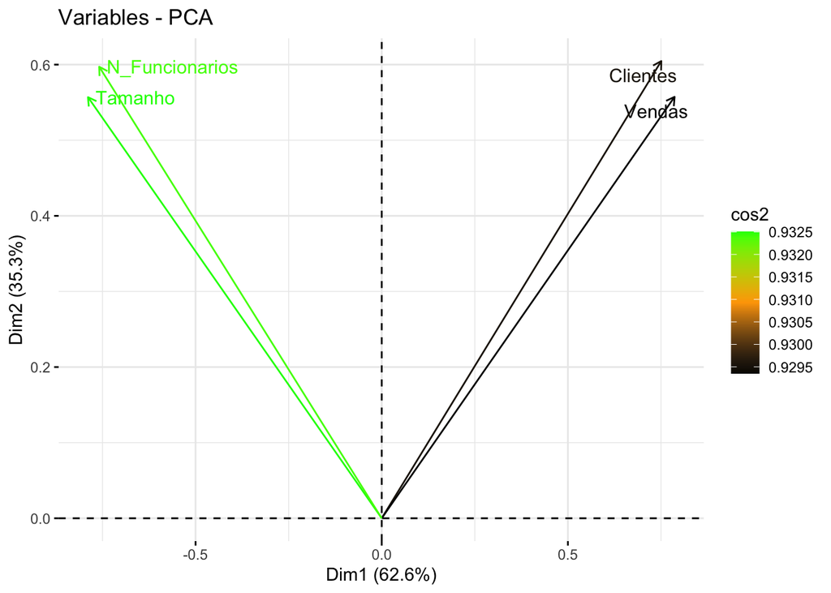

```r
fviz_pca_var(resultado, col.var = "cos2",
             gradient.cols = c("black", "orange", "green"),
             repel = TRUE)
```